# **About Me.**

As a GIS major in college and **Master of Urban Spatial Analytics** candidate at the **University of Pennsylvania**, I have been using ESRI ArcGIS products and other tools to process, analyze, and visualize data for nearly 5 years. I have always hoped that I can bring my expertise in data analytics and visualization to help thousands of people lead a better life. Outside of my work, other interests include gymnastics judging, archaeology, and orienteering.  
You can reach me at yixuanhu@upenn.edu

Here are the skills I possess:

- Analytics
- Statistics
- Machine Learning
- Spatial Analysis
- Databases
- R, Python, JavaScript, C#, etc
- Visualization
- Spatial and Non-spatial Data
- 2D/3D Interactive Mapping
- Web Design
- Layout Design
- ArcGIS Tools, R, HTML, JavaScript, etc

# **Analytics Showcase.**

Housing prices, transportation, urban development, global trend, etc. Please click to enlarge images for more information.

[figure not shown]

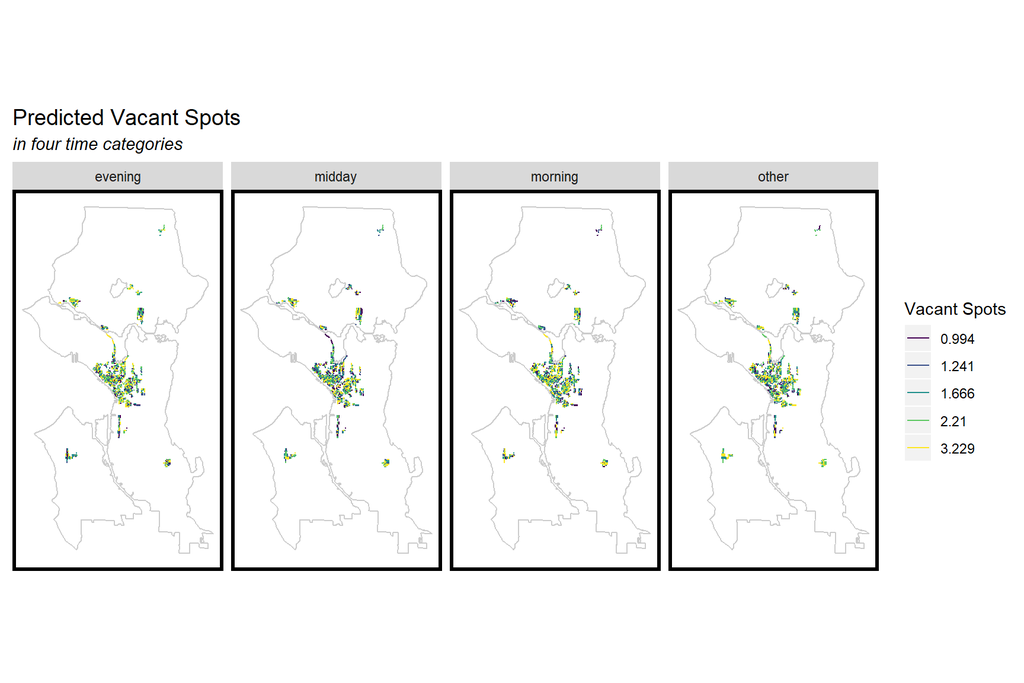

[figure not shown]

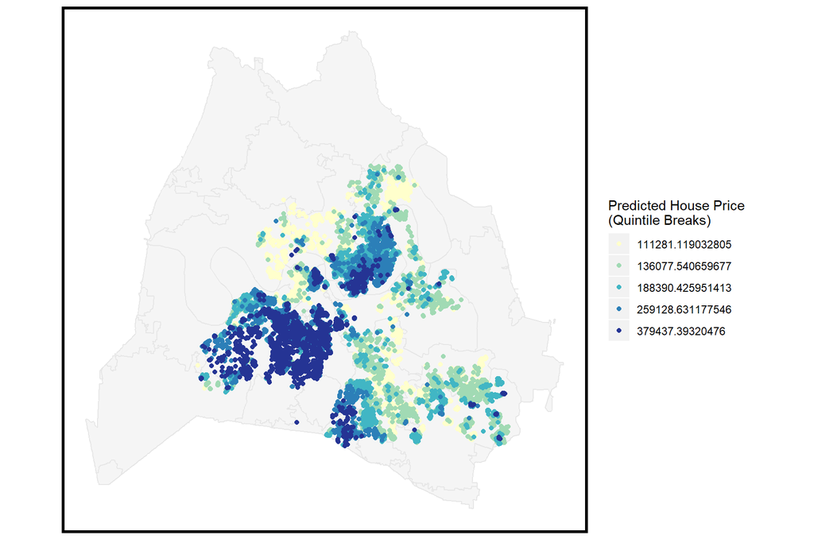

[figure not shown]

[figure not shown]

# **Thematic Interactive Map.**

**Who and Where**: a thematic map about the age distribution of high-income households across NYC. Please click the arrow at upperleft corner for legend.

[interactive chart not shown]

# **3D Visualization.**

**Beyond Points**: a visualization of buildings over 200m in Manhattan

[interactive chart not shown]